# R Notebook

# A Data-Driven Analysis of Football Player Performance and Wage

**Football** is one of the most popular sports in the world, enjoyed by billions of fans and generating huge amounts of money through TV rights, sponsorships, and merchandise. Because of this, football players often earn some of the highest salaries in professional sports. Clubs spend a lot of money on players based on their skills, physical abilities, and overall performance.

This project is divided into two major components:

1. **EDA** - We will start with exploratory data analysis, and see the connection between player performance and salary to understand what factors influence how much footballers get paid.
2. **Regression model** - Then, we will use regression modeling to see how different performance metrics affect player wages, giving us insights into what really drives player value in football.

## Data

The dataset used in this project was sourced from [SoFIFA](https://sofifa.com/players?type=all&col=wg&sort=desc), a platform that provides detailed information on football players from various leagues worldwide. The data reflects player statistics as of **the end of 2024**

The dataset includes the following key information:

- **Personal Details:** Player name, age, preferred foot, height, and weight.
- **Club & Contract:** League, contract duration, release clauses.
- **Performance Metrics:** Technical skills (e.g., finishing, dribbling), physical attributes (e.g., sprint speed, stamina), and mental attributes (e.g., vision, composure).
- **Market Value:** Estimated player value and salary information.
- **Positional Data:** Best position and player role (attacker, midfielder, defender, goalkeeper).

### Data Manipulation

```r
league_rankings <- data.frame(
  League = c( "Süper Lig (Türkiye)", "Liga Profesional de Fútbol (Argentina)",
             "Eredivisie (Netherlands)", "Série A (Brazil)", "Primeira Liga (Portugal)", "Ligue 1 (France)",
             "Serie A (Italy)", "Bundesliga (Germany)", "La Liga (Spain)", "Premier League (England)"),
  League_Rank = 10:1
)
numeric_vars <- c("Finishing", "Dribbling", "Shot.Power", "Sprint.Speed",
                  "Attack.Position", "Short.Passing", "Vision", "Long.Passing",
                  "Stamina", "Standing.Tackle", "Interceptions", "Strength",
                  "Defensive.Awareness", "Heading.Accuracy", "GK.Reflexes",
                  "GK.Diving", "GK.Handling", "GK.Positioning","Overall.Score",
                  "Potential.Score", "Composure", "Reactions","International.Reputation", "Aggression",
                  "Total.Movement", "Total.Power", "Total.Defending", "Total.Mentality", "Total.Stats" )


df_clean<- df %>%
  left_join(league_rankings, by = "League") %>%
  mutate(
    Wage = as.numeric(str_replace_all(str_remove_all(Wage, "€"), c("K" = "000", "M" = "000000"))),
    Value = as.numeric(str_replace_all(str_remove_all(Value, "€"), c("K" = "000", "M" = "000000"))),
    Release.Clause = as.numeric(str_replace_all(str_remove_all(Release.Clause, "€"), c("K" = "000", "M" = "000000"))),
    Contract.Start = as.numeric(Contract.Start),
    Contract.End = as.numeric(Contract.End),
    Contract.Duration=Contract.End-Contract.Start,
    Height_cm = as.numeric(str_extract(Height, "\\d+")),
    Weight_kg = as.numeric(str_extract(Weight, "\\d+")),
    across(all_of(numeric_vars),
                ~ as.numeric(str_remove(., "\\+\\d+"))),
    Role = case_when(
      str_detect(Best.Position, "LW|RW") ~ "Winger",
      str_detect(Best.Position, "ST|CF") ~ "Striker",
      str_detect(Best.Position, "CM|CAM|CDM") ~ "Central Midfielder",
      str_detect(Best.Position, "CB") ~ "Central Defender",
      str_detect(Best.Position, "RWB|LWB|LB|RB") ~ "Side Defender",
      str_detect(Best.Position, "LM|RM") ~ "Side Midfielder",
      TRUE ~ "Unknown"
  ),
  LeagueRanked = paste0("#", League_Rank, " ", League)
  ) %>%
  filter(Role != "Unknown", !is.na(Overall.Score), !is.na(Wage),   !is.na(Contract.Duration), League %in% league_rankings$League, Best.Position != "GK")%>%
    select(
    -c(Position, Player.ID, Loan.End, Attacking.Work.Rate, Defensive.Work.Rate,
       Source_File, Joined.Team, Height, Weight, Real.Face, Body.Type,
       Contract.Start, Contract.End, Total.Goalkeeping),
    -matches("GK.")
  )

#Calculate median overall and potential scores across all players
median_overall <- df_clean %>%
  summarise(median_value = median(Overall.Score, na.rm = TRUE)) %>%
  pull(median_value)  # Converts it to a vector

median_potential <- df_clean %>%
  summarise(median_value = median(Potential.Score, na.rm = TRUE)) %>%
  pull(median_value)


#Assign performance categories
df_clean<-df_clean %>% mutate( 'Performance Category' = case_when(
      Overall.Score >= median_overall & Potential.Score >=median_potential ~ "Emerging High Performers",  # "High Overall, High Potential"
      Overall.Score >= median_overall & Potential.Score < median_potential ~ "High Peak Performers", # "High Overall, Low Potential"
      Overall.Score < median_overall & Potential.Score >= median_potential ~ "Future High Performers", #  "Low Overall, High Potential"
      Overall.Score < median_overall & Potential.Score < median_potential ~ "Limited Performance" # "Low Overall, Low Potential"
    )) %>%
  group_by(LeagueRanked) %>%
  mutate(Total_Count = n()) %>%

  group_by(LeagueRanked, `Performance Category`) %>%
  mutate(Count = n()) %>%

   mutate(Percentage = round((Count / Total_Count) * 100, 0)) %>%
  group_by(LeagueRanked) %>%
  mutate(
    x_pos = case_when(
      `Performance Category` == "Emerging High Performers" ~ 90,
      `Performance Category` == "High Peak Performers" ~ 90,
      `Performance Category` == "Future High Performers" ~ 50,
      `Performance Category` == "Limited Performance" ~ 50
    ),
    y_pos = case_when(
      `Performance Category` == "Emerging High Performers" ~ 95,
      `Performance Category` == "High Peak Performers" ~ 55,
      `Performance Category` == "Future High Performers" ~ 95,
      `Performance Category` == "Limited Performance" ~ 55
    )
  ) %>%

  ungroup()



head(df_clean)
```

| Player | League | Age | Overall.Score | Potential.Score | Preferred.Foot | Best.Overall | Best.Position | Growth | Value | Wage | Release.Clause | Total.Attacking.Score | Crossing | Finishing | Heading.Accuracy | Short.Passing | Volleys | Total.Skill | Dribbling | Curve | FK.Accuracy | Long.Passing | Ball.Control | Total.Movement | Acceleration | Sprint.Speed | Agility | Reactions | Balance | … |
| --- | --- | --- | --- | --- | --- | --- | --- | --- | --- | --- | --- | --- | --- | --- | --- | --- | --- | --- | --- | --- | --- | --- | --- | --- | --- | --- | --- | --- | --- | --- |
| Harry Kane | Bundesliga (Germany) | 30 | 90 | 90 | Right | 90 | ST | 0 | 1.175e+02 | 170000 | 1.939e+02 | 441 | 80 | 95 | 91 | 86 | 89 | 408 | 82 | 82 | 69 | 88 | 87 | 363 | 64 | 66 | 66 | 94 | 73 | … |
| Florian Wirtz | Bundesliga (Germany) | 21 | 88 | 92 | Right | 90 | CAM | 4 | 1.335e+02 | 115000 | 2.303e+02 | 376 | 84 | 79 | 42 | 91 | 80 | 418 | 90 | 82 | 69 | 87 | 90 | 424 | 81 | 81 | 87 | 88 | 87 | … |
| Jamal Musiala | Bundesliga (Germany) | 21 | 87 | 93 | Right | 89 | CAM | 6 | 1.280e+08 | 87000 | 2.368e+02 | 364 | 67 | 84 | 56 | 84 | 73 | 391 | 94 | 75 | 59 | 79 | 84 | 442 | 86 | 83 | 93 | 87 | 93 | … |
| Joshua Kimmich | Bundesliga (Germany) | 29 | 86 | 86 | Right | 86 | RB | 0 | 5.950e+01 | 105000 | 9.820e+01 | 388 | 91 | 68 | 72 | 88 | 69 | 422 | 82 | 85 | 79 | 91 | 85 | 394 | 77 | 62 | 83 | 88 | 84 | … |
| Granit Xhaka | Bundesliga (Germany) | 31 | 86 | 86 | Left | 86 | CDM | 0 | 4.750e+01 | 130000 | 7.840e+01 | 356 | 77 | 67 | 68 | 89 | 55 | 404 | 73 | 80 | 78 | 90 | 83 | 298 | 48 | 52 | 51 | 86 | 61 | … |
| Alejandro Grimaldo García | Bundesliga (Germany) | 28 | 86 | 86 | Left | 86 | LM | 0 | 6.850e+01 | 135000 | 1.130e+08 | 372 | 93 | 67 | 62 | 87 | 63 | 434 | 85 | 89 | 89 | 85 | 86 | 404 | 77 | 71 | 84 | 86 | 86 | … |

## EDA

### Amount of players across Top Football Leagues

Sorted by League Rank

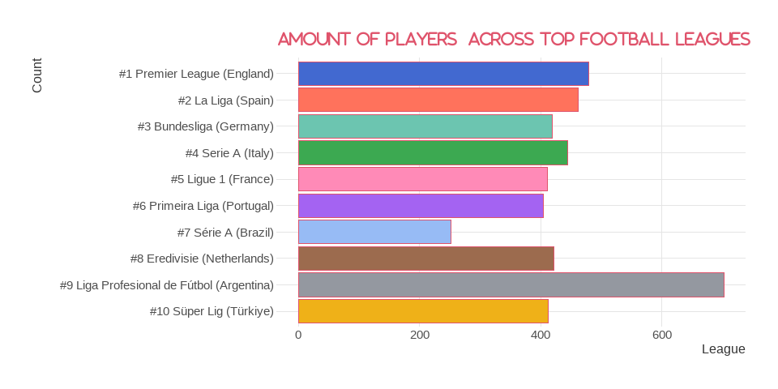

When looking at the player distribution across the top football leagues, it’s clear that most leagues have a similar number of players, usually between **400 and 500**. However, there are noticeable differences, especially in the **Argentine** and **Brazilian** leagues.

The **Argentine Primera División** has **28 clubs**, which is more than the usual **20 clubs** found in most top leagues. This larger number of teams naturally leads to a higher total number of registered players. In contrast, the **Campeonato Brasileiro Série A** has **20 clubs**, similar to many major European leagues.

Even with the same number of clubs, differences in **player registration rules** and **squad management** can cause variations in the total number of players across leagues.

### Overall Score and Age Distribution Across Top Football Leagues

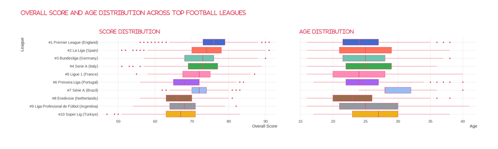

### Graph #2.

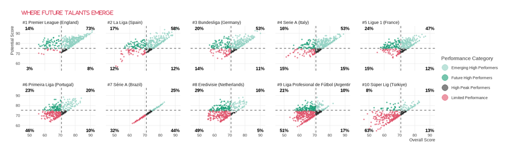

### Graph #3.

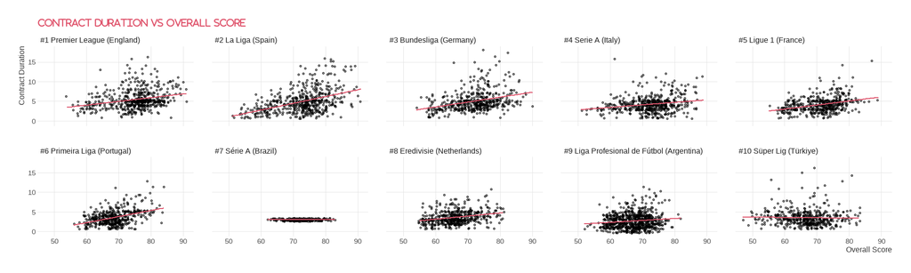

```r
ggplot(df_clean) +
  aes(x = Overall.Score, y = Contract.Duration) +
 geom_jitter( alpha = 0.5) +
  scale_fill_observable()+
geom_smooth(method = "lm", color = "666666", linetype = "solid", se = FALSE) +
 facet_wrap(vars(reorder(LeagueRanked, League_Rank)), ncol = 5L)+
  labs(title = "Contract Duration Vs Overall Score", x = "Overall Score", y = "Contract Duration") +
  theme( legend.position = "right",plot.title = element_text(size = 14))
```

## Multi-Linear Regression Models

```r
# Performance_Score= case_when(
# str_detect(Role, "Attacker") \~ (5 \* as.numeric(Finishing)) +
# (4 \* as.numeric(Dribbling)) +
# (3 \* as.numeric(Shot.Power)) +
# (2 \* as.numeric(Sprint.Speed))+
# (1 \* as.numeric(Attack.Position)),
# str_detect(Role, "Midfielder") \~ (5 \* as.numeric(Short.Passing)) +
# (3 \* as.numeric(Dribbling)) +
# (4 \* as.numeric(Vision)) +
# (2 \* as.numeric(Long.Passing)) +
# (1 \* as.numeric(Stamina)),
# str_detect(Role, "Defender") \~ (5 \* as.numeric(Standing.Tackle)) + \
# (4 \* as.numeric(Interceptions)) + \
# (3 \* as.numeric(Strength)) + \
# (2 \* as.numeric(Defensive.Awareness)) + \
# (1 \* as.numeric(Heading.Accuracy)), \
# str_detect(Role, "Goalkeeper") \~ (5 \* as.numeric(GK.Reflexes)) + \
# (4 \* as.numeric(GK.Diving)) + \
# (3 \* as.numeric(GK.Handling)) + \
# (2 \* as.numeric(GK.Positioning))+ \
# (1 \* as.numeric(GK.Positioning)), \
# TRUE \~ as.numeric(Overall.Score) \
# Default if no match \# ),

# Example: Predicting Player Value
model0 <- lm( Wage/1000 ~ Finishing+ Dribbling+ Shot.Power+ Sprint.Speed+Attack.Position,
            data = df_clean%>% filter(Role=="Attacker"))
model1 <- lm(Wage/1000 ~ Finishing+ Dribbling+ Shot.Power+ Sprint.Speed+Attack.Position+ Short.Passing+Vision+Long.Passing+Stamina+Standing.Tackle+Interceptions+Strength+Defensive.Awareness+Heading.Accuracy+Age,
            data = df_clean%>% filter(Role=="Attacker"))

model_improved <- lm(Wage/1000 ~Total.Movement+ Total.Power+ Total.Defending+Total.Mentality+Total.Stats ,   data = df_clean)

# model2 <- lm(Overall.Score ~ Finishing+ Dribbling+ Shot.Power+ Sprint.Speed+Attack.Position+ Short.Passing+Vision+Long.Passing+Stamina+Standing.Tackle+Interceptions+Strength+Defensive.Awareness+Heading.Accuracy+Age,
#             data = df_clean%>% filter(Role=="Midfielder"))
# model3 <- lm(Overall.Score ~ Finishing+ Dribbling+ Shot.Power+ Sprint.Speed+Attack.Position+ Short.Passing+Vision+Long.Passing+Stamina+Standing.Tackle+Interceptions+Strength+Defensive.Awareness+Heading.Accuracy+Age,
#             data = df_clean%>% filter(Role=="Defender"))

# Summary of Model
summary(model0)
```

[output not shown]

```r
summary(model1)
```

[output not shown]

```r
summary(model_improved)
```

```
Call:
lm(formula = Wage/1000 ~ Total.Movement + Total.Power + Total.Defending +
    Total.Mentality + Total.Stats, data = df_clean)

Residuals:
   Min     1Q Median     3Q    Max
-48.50 -15.10  -5.09   7.51 534.25

Coefficients:
                  Estimate Std. Error t value Pr(>|t|)
(Intercept)     -1.027e+02  3.536e+00 -29.044  < 2e-16 ***
Total.Movement  -2.097e-01  1.427e-02 -14.695  < 2e-16 ***
Total.Power     -7.625e-02  1.820e-02  -4.188 2.86e-05 ***
Total.Defending -4.024e-02  9.402e-03  -4.280 1.90e-05 ***
Total.Mentality -4.511e-01  2.376e-02 -18.988  < 2e-16 ***
Total.Stats      2.064e-01  8.021e-03  25.730  < 2e-16 ***
---
Signif. codes:  0 ‘***’ 0.001 ‘**’ 0.01 ‘*’ 0.05 ‘.’ 0.1 ‘ ’ 1

Residual standard error: 28.22 on 4995 degrees of freedom
Multiple R-squared:  0.2655,    Adjusted R-squared:  0.2647
F-statistic: 361.1 on 5 and 4995 DF,  p-value: < 2.2e-16
```

```r
# 5 assumptions
#1. linear
#2. independent error -> Durban watson test
#3. Homoscedasticity -> Residual plot
#4. Normally distribution -> QQ plot
#5. Multicollinearity VIF, Tolerance
```

```r
library(car)
#Check for Multicollinearity
vif(model0)
```

[output not shown]

[figure not shown]

```r
# Residual Diagnostics
par(mfrow = c(2, 2))
plot(model0)
```

```r
cor(df_clean %>% select(Finishing, Dribbling, Shot.Power, Sprint.Speed, Attack.Position), use = "complete.obs")
```

```
                Finishing Dribbling Shot.Power Sprint.Speed Attack.Position
Finishing       1.0000000 0.8559908  0.7524894    0.6161960       0.9189848
Dribbling       0.8559908 1.0000000  0.6227002    0.7413640       0.9227420
Shot.Power      0.7524894 0.6227002  1.0000000    0.3893394       0.6968678
Sprint.Speed    0.6161960 0.7413640  0.3893394    1.0000000       0.6831858
Attack.Position 0.9189848 0.9227420  0.6968678    0.6831858       1.0000000
```

```r
cor(df_clean %>% select(Total.Movement,Total.Power, Total.Defending,Total.Mentality,Total.Stats), use = "complete.obs")
```

```
                Total.Movement Total.Power Total.Defending Total.Mentality Total.Stats
Total.Movement       1.0000000   0.6535119       0.3262926       0.7361258   0.8172760
Total.Power          0.6535119   1.0000000       0.4471170       0.8496308   0.8912933
Total.Defending      0.3262926   0.4471170       1.0000000       0.6771953   0.6091527
Total.Mentality      0.7361258   0.8496308       0.6771953       1.0000000   0.9641903
Total.Stats          0.8172760   0.8912933       0.6091527       0.9641903   1.0000000
```

```r
cor(df_clean %>% select(Finishing, Dribbling, Shot.Power, Sprint.Speed, Attack.Position), use = "complete.obs")
```

[output not shown]

```r
model_poly <- lm(Overall.Score ~ Finishing + I(Finishing^2) + Dribbling + I(Dribbling^2) +
                   Shot.Power + Sprint.Speed + Attack.Position,
                 data = df_clean %>% filter(Role == "Attacker"))
summary(model_poly)
```

[output not shown]

[figure not shown]

```r
#library(esquisse)
#esquisser(df_clean)
library(dplyr)
library(ggplot2)

df_clean %>%
 filter(Role %in% "Attacker") %>%
 ggplot() +
 aes(x = Finishing, y = Overall.Score, colour = `Performance Category`) +
 geom_jitter() +
 scale_color_hue(direction = 1) +
 hrbrthemes::theme_ipsum_ps()
```

[figure not shown]

```r
df_clean %>%
 filter(Role %in% "Attacker") %>%
 filter(!is.na(`Performance Category`)) %>%
 ggplot() +
 aes(x = Finishing, y = Overall.Score, colour = `Performance Category`) +
 geom_jitter() +
 scale_color_hue(direction = 1) +
 labs(caption = "the ability to place the ball precisely") +
 hrbrthemes::theme_ipsum_ps()
```

[figure not shown]

```r
df_clean %>%
 filter(!is.na(`Performance Category`)) %>%
 ggplot() +
 aes(x = Finishing, y = Overall.Score, colour = `Performance Category`) +
 geom_jitter() +
 scale_color_hue(direction = 1) +
 labs(caption = "the ability to place the ball precisely") +
 hrbrthemes::theme_ipsum_ps() +
 facet_wrap(vars(Role))
```

[figure not shown]

```r
df_clean %>%
 filter(!is.na(`Performance Category`)) %>%
 ggplot() +
 aes(x = Dribbling, y = Overall.Score, colour = `Performance Category`) +
 geom_jitter() +
 scale_color_hue(direction = 1) +
 labs(caption = "Skill in controlling the ball while moving") +
 hrbrthemes::theme_ipsum_ps() +
 facet_wrap(vars(Role))
```

[figure not shown]

```r
df_clean %>%
 filter(!is.na(`Performance Category`)) %>%
 ggplot() +
 aes(x = Dribbling, y = Overall.Score, colour = `Performance Category`) +
 geom_jitter() +
 scale_color_hue(direction = 1) +
 labs(caption = "Skill in controlling the ball while moving") +
 hrbrthemes::theme_ipsum_ps() +
 facet_wrap(vars(Role))
```

[figure not shown]

```r
df_clean %>%
 filter(!is.na(`Performance Category`)) %>%
 ggplot() +
 aes(x = Dribbling, y = Overall.Score, colour = `Performance Category`) +
 geom_jitter() +
 scale_color_hue(direction = 1) +
 labs(caption = "Skill in controlling the ball while moving") +
 hrbrthemes::theme_ipsum_ps() +
 facet_wrap(vars(Role))
```

[figure not shown]

```r
df_clean %>%
 filter(!is.na(`Performance Category`)) %>%
 ggplot() +
 aes(x = Dribbling, y = Overall.Score, colour = `Performance Category`) +
 geom_jitter() +
 scale_color_hue(direction = 1) +
 labs(caption = "Skill in controlling the ball while moving") +
 hrbrthemes::theme_ipsum_ps() +
 facet_wrap(vars(Role))
```

[figure not shown]

```r
df_clean %>%
 filter(!is.na(`Performance Category`)) %>%
 ggplot() +
 aes(x = Shot.Power, y = Overall.Score, colour = `Performance Category`) +
 geom_point() +
 scale_color_hue(direction = 1) +
 labs(caption = "Skill in controlling the ball while moving") +
 hrbrthemes::theme_ipsum_ps() +
 facet_wrap(vars(Role))
```

[figure not shown]

```r
df_clean %>%
 filter(!is.na(`Performance Category`)) %>%
 ggplot() +
 aes(x = Shot.Power, y = Overall.Score, colour = `Performance Category`) +
 geom_point() +
 scale_color_hue(direction = 1) +
 labs(caption = "Strength behind a player's shot") +
 hrbrthemes::theme_ipsum_ps() +
 facet_wrap(vars(Role))
```

[figure not shown]

```r
df_clean %>%
 filter(!is.na(`Performance Category`)) %>%
 ggplot() +
 aes(x = Attack.Position, y = Overall.Score, colour = `Performance Category`) +
 geom_point() +
 scale_color_hue(direction = 1) +
 labs(caption = " Intelligence in getting into goal-scoring areas") +
 hrbrthemes::theme_ipsum_ps() +
 facet_wrap(vars(Role))
```

[figure not shown]

```r
df_clean %>%
 filter(!is.na(`Performance Category`)) %>%
 ggplot() +
 aes(x = Short.Passing, y = Overall.Score, colour = `Performance Category`) +
 geom_point() +
 scale_color_hue(direction = 1) +
 labs(caption = "Skill in precise passing over short distances") +
 hrbrthemes::theme_ipsum_ps() +
 facet_wrap(vars(Role))
```

[figure not shown]

```r
df_clean %>%
 filter(!is.na(`Performance Category`)) %>%
 ggplot() +
 aes(x = Vision, y = Overall.Score, colour = `Performance Category`) +
 geom_point() +
 scale_color_hue(direction = 1) +
 labs(caption = "Skill in identifying gaps for key passes") +
 hrbrthemes::theme_ipsum_ps() +
 facet_wrap(vars(Role))
```

[figure not shown]

```r
df_clean %>%
 filter(!is.na(`Performance Category`)) %>%
 ggplot() +
 aes(x = Long.Passing, y = Overall.Score, colour = `Performance Category`) +
 geom_point() +
 scale_color_hue(direction = 1) +
 labs(caption = " Accuracy in passing over long distances") +
 hrbrthemes::theme_ipsum_ps() +
 facet_wrap(vars(Role))
```

[figure not shown]

```r
df_clean %>%
 filter(!is.na(`Performance Category`)) %>%
 ggplot() +
 aes(x = Stamina, y = Overall.Score, colour = `Performance Category`) +
 geom_point() +
 scale_color_hue(direction = 1) +
 labs(caption = "Physical capacity to perform consistently over time") +
 hrbrthemes::theme_ipsum_ps() +
 facet_wrap(vars(Role))
```

[figure not shown]

```r
df_clean %>%
 filter(!is.na(`Performance Category`)) %>%
 ggplot() +
 aes(x = Standing.Tackle, y = Overall.Score, colour = `Performance Category`) +
 geom_point() +
 scale_color_hue(direction = 1) +
 labs(caption = "Skill in cleanly taking the ball without sliding") +
 hrbrthemes::theme_ipsum_ps() +
 facet_wrap(vars(Role))
```

```r
#install.packages("gganimate")
#install.packages("gifski")

library(ggplot2)
library(gganimate)
avg_age<-df_clean%>% group_by(League, Age) %>% summarise(Growth=mean(Growth))
p <- ggplot(avg_age, aes(x = Age, y = Growth, color = League, group = League)) +
  geom_line(size = 1.2, alpha = 0.8) +  # Line plot for trends
  geom_point(size = 2) +  # Points for better visibility
  scale_color_manual(values = c("#E07B39", "#3498db", "#2ecc71", "#f1c40f", "#9b59b6",
                   "#ff5733", "#16a085", "#8e44ad", "#c0392b", "#2c3e50", "#d35400")) +  # Custom colors for Leagues
  labs(title = "Average Growth by Age Across Leagues",
       subtitle = "Age: {frame_along}",
       x = "Age",
       y = "Growth",
       color = "League") +
  theme_minimal(base_size = 14) +
  theme(
    plot.title = element_text(size = 18, hjust = 0.5, face = "bold"),
    plot.subtitle = element_text(size = 16, hjust = 0.5),
    axis.title = element_text(size = 14, face = "bold"),
    legend.position = "right"
  ) +
  transition_reveal(Age)  # Animate Age progression

# Save as GIF
animate(p, duration = 10, fps = 10, width = 800, height = 600, renderer = gifski_renderer("age_growth_league.gif"))
```

```r
ggplot(data=df_clean, aes(x=Wage_K, y=Performance_Score))+
  geom_point()+
  facet_wrap(~League)



ggplot(data=england, aes(x=log(Wage_K), y=Performance_Score, color=Role))+
  geom_point()


lm_model <- lm(log(Wage) ~ Performance_Score, data = df_clean)
summary(lm_model)

ggplot(data=england, aes(x=Wage_K, y=Performance_Score, color = Performance_Score))+
  geom_point(alpha = 0.8, size = 3)+
  geom_smooth(method = "lm", linetype = "dashed", color = "white", se = FALSE)+
  scale_x_continuous(labels = scales::comma, name = "Wage (in K)") +
  theme_minimal()



df%>% distinct(League)

# H1: relationship between player wage and their performance

top_players <- england%>% filter(Wage_K>240)

# Create the scatter plot
p <- ggplot(data = england, aes(x = Wage_K, y = Performance_Score, color = Performance_Score, text = mylabel)) +

  # Scatter points with gradient color
  geom_boxplot(alpha = 0.8, size = 4) +

  # Add regression line (trend)
  geom_smooth(method = "lm", linetype = "dashed", color = "white", se = FALSE) +

  # Highlight key players
  geom_text_repel(data = top_players, aes(label = Player), size = 5, color = "white", force = 2,  # Reduce overlap
                  nudge_y = 50,  # Move text upwards slightly
                  direction = "y" ) +

  # Custom color gradient
  scale_color_gradient(low = "#AABCCB", high = "#E07B39") +

  # Format X-axis (Wage) with € and K
  scale_x_continuous(
    labels = function(x) paste0("€", x, "K"),
    breaks = seq(0, 500, by = 100),
    name = "Wage"
  ) +

  # Format Y-axis (Performance Score)
  scale_y_continuous(name = "Performance Score") +

  # Apply dark theme and enhance visibility
  theme_minimal(base_size = 14) +
  theme(
    panel.background = element_rect(fill = "#012030", color = NA),  # Dark background
    panel.grid.major = element_line(color = "#1F3A52", size = 0.3),
    panel.grid.minor = element_blank(),
    plot.background = element_rect(fill = "#012030", color = NA),
    plot.title = element_text(color = "white", size = 20, face = "bold"),
    axis.text = element_text(color = "white", size = 12),
    axis.title = element_text(color = "white", size = 14),
    legend.position = "none"
  ) +

  # Add title and caption
  labs(title = "Wage Vs Performance in  Premier League  Englan League", caption = "Data Source: FIFA Stats")

# Convert to interactive plot with tooltips


annotations_list <- lapply(1:nrow(top_players), function(i) {
  list(
    x = top_players$Wage_K[i],
    y = top_players$Performance_Score[i],
    text = paste0(top_players$Player[i]),
    showarrow = TRUE,
    arrowhead = 0,
    ax = 0, ay = -10,
    font = list(color = "white", size = 12)
  )
})


ggplotly(p, tooltip = c("mylabel")) %>%
  layout(annotations = annotations_list)





# H1: Certain positions receive higher wages

# Compute average wage per Role & League
# Compute average wage per Role & League
avg_wage <- df_clean %>%
  filter(League %in% c("Premier League (England)", "La Liga (Spain)",
                       "Bundesliga (Germany)", "Serie A (Italy)", "Ligue 1 (France)")) %>%
  group_by(League, Role) %>%
  summarise(Wage_K = mean(Wage_K, na.rm = TRUE), .groups = "drop") %>%

  # Sort leagues by highest average wage (descending)
  arrange(desc(Wage_K)) %>%

  # Convert League to factor with ordered levels
  mutate(League = factor(League, levels = unique(League)))

# Define custom colors for roles
role_colors <- c("Goalkeeper" = "green",
                 "Defender" = "blue",
                 "Midfielder" = "purple",
                 "Attacker" = "red")

# Create bar chart with sorted leagues & larger facet labels
p <- ggplot(data = avg_wage, aes(x = Role, y = Wage_K, fill = Role)) +

  geom_col(alpha = 0.8, width = 0.6) +  # Use geom_col() for single values

  facet_wrap(~League, scales = "free_y") +  # Allow different y-axis ranges per league

  scale_fill_manual(values = role_colors, name = "Player Role") +  # Add legend with custom colors

  # Increase facet label size
  theme_minimal(base_size = 14) +
  theme(
    strip.text = element_text(size = 16, face = "bold", color = "white"),  # Bigger facet labels
    panel.background = element_rect(fill = "#012030", color = NA),
    panel.grid.major = element_line(color = "#1F3A52", size = 0.3),
    panel.grid.minor = element_blank(),
    plot.background = element_rect(fill = "#012030", color = NA),
    plot.title = element_text(color = "white", size = 20, face = "bold"),
    axis.text = element_text(color = "white", size = 12),
    axis.title = element_text(color = "white", size = 14),

    # Position the legend on the right side
    legend.position = "right",
    legend.text = element_text(color = "white", size = 12),
    legend.title = element_text(color = "white", size = 14, face = "bold")
  ) +

  labs(title = "Average Wage by Role Across Leagues",
       x = "Player Role",
       y = "Wage (€K)",
       caption = "Data Source: FIFA Stats")

# Convert to interactive plot
ggplotly(p)
```

[output not shown]